# Basics of Python by Mohammad Wasiq

# Python Libraries :

Python Libraries is a collection of functiona and methods that allows to perform many actions without writing your code .

### (I) NumPy

### (II) Matplotlib

### (III) Pandas

### (IV) SeaBorn

## (I) NumPy:

NumPy stands for Numerical python and is the core library for numeric and scientific computing .  
Importing/Loading the NumPy Library:- *import numpy as np*

## Array:

Ceating a Single dimensional Array :  
* **Syntax: np.array([elements])**

### Creating a Multi dim-array :

**Syntax: np.array([[elements_1],[elements_2],....,[elements_n]])**  
Type of array:- **type(array_name)**  
*Zero array :- **np.zeros((dim))***  
Same element aray:- **np.full((dim),element)**  
*Array Dimension/Shape:- **array_name.shape***  
To Change the Array Dimension/Shape:- **array_name.shape=(new_dim)**  
*Array within a range 'a' to 'b' by 'c':- **np.arange(a,b,c)***  
Array with random number 'a' to 'b' with size 'c':- **np.random.randint(a,b,c)**  
*To joining the array 'a' and array 'b' vertically :- **np.vstack((a,b))***  
To joining the array 'a' and array 'b' horizontally :- **np.hstack((a,b))**  
*To joining the array 'a' and array 'b' column-wise :- **np.column_stack((a,b))***  
To joining the array 'a' and array 'b' row-wise :- **np.row_stack((a,b))**  
*Common element from both arrays 'a' & 'b' :- **np.intersect1d(a,b)***  
Remove the common element fom both arrays 'a' & 'b' :- **np.setdiff1d(a,b)**  
*Addition of two arrays 'a' & 'b':- **np.sum(a, b)***  
Addition of two arrays 'a' & 'b' column-wise:- **np.sum(a, b , axis=0)**  
*Addition of two arrays 'a' & 'b' row-wise:- **np.sum(a, b , axis=1)***  
Subtraction of two arrays 'a' & 'b' :- **np.subtract(a,b)**  
*Multiplication of two arrays 'a' & 'b' :- **np.multiply(a,b)***  
Division of two arrays 'a' & 'b' :- **np.divide(a,b)**  
*Square root of array 'b' :- **np.sqrt(b)***  
Exponentiation of array 'b' :- **np.exp(b)**  
*sines of an array 'b' :- **np.sin(a) Print***  
Element-wise cosine of array 'b' :- **np.cos(b)**  
*Element-wise natural logarithm of array 'a' :- **np.log(a)***  
Dot product of array :- **e.dot(f)**  
*Multiple , Divide , Add, Subtract the arrays 'a' by 'n' :- **an , a/n , a+n ,a-n***  
Transpose of an array 'b' :- **np.transpose(b)** i.e **b.T**  
*Mean of array 'a' :- **np.mean(a)***  
Standard Deviation of array 'a':- **np.std(a)**  
*Median of array 'a':- **np.median(a)***  
Correlation Coefficient of array 'a' :- **a.corrcoef()**  
*Save the array 'a' by name 'b' :- **np.save('b',a)***  
load the array 'b' :- **np.load('b.npy')**

```python
# Importing/Loading the NumPy Library
import numpy as np
```

```python
# Define an Array
n1=np.array([10,11,13,14]) # 1*4 mtx
n1
```

```
array([10, 11, 13, 14])
```

```python
n2 = np.array([[12,13,14,15],[35,36,36,37],[42,43,44,45],[51,52,53,54]])
n2 # 4*4 mtx
```

```
array([[12, 13, 14, 15],
       [35, 36, 36, 37],
       [42, 43, 44, 45],
       [51, 52, 53, 54]])
```

```python
type(n2)
```

```
numpy.ndarray
```

```python
# Initializing NumPy arrays with zeros
n3=np.zeros((1,2)) # give zero array of dim 1*2
n3
```

```
array([[0., 0.]])
```

```python
nn3=np.zeros((5,5)) # give zero array of dim 5*5
nn3
```

```
array([[0., 0., 0., 0., 0.],
       [0., 0., 0., 0., 0.],
       [0., 0., 0., 0., 0.],
       [0., 0., 0., 0., 0.],
       [0., 0., 0., 0., 0.]])
```

```python
# Initializing NumPy arrays with zeros
ss1=np.full((2,2),10)
ss1
```

```
array([[10, 10],
       [10, 10]])
```

```python
# Initializing NumPy arrays within a range
ra1=np.arange(10,20)
ra1
```

```
array([10, 11, 12, 13, 14, 15, 16, 17, 18, 19])
```

```python
ra=np.arange(10,50,5)
ra
```

```
array([10, 15, 20, 25, 30, 35, 40, 45])
```

```python
# Initializing NumPy arrays with random numbers
rn1=np.random.randint(1,100,5)
rn1
```

```
array([36, 50, 37,  2, 28])
```

```python
r1 = np.array([[1,2,3],[4,5,6],[7,8,9],[10,11,12]])
r1.shape
```

```
(4, 3)
```

```python
r1.shape=(3,4)
r1
```

```
array([[ 1,  2,  3,  4],
       [ 5,  6,  7,  8],
       [ 9, 10, 11, 12]])
```

```python
# Joining the NumPy Arrays
r2 = np.array([1,2,3])
r3 = np.array([4,5,6])
np.vstack((r2,r3)) # To join vertical-wise
```

```
array([[1, 2, 3],
       [4, 5, 6]])
```

```python
np.hstack((r2,r3)) # To join horizontal-wise
```

```
array([1, 2, 3, 4, 5, 6])
```

```python
np.column_stack((r2,r3)) # to join column-wise
```

```
array([[1, 4],
       [2, 5],
       [3, 6]])
```

```python
np.row_stack((r2,r3))
```

```
array([[1, 2, 3],
       [4, 5, 6]])
```

```python
# Intersection & Difference NumPy Arrays
r2 = np.array([1,5,3])
r3 = np.array([4,5,6])
np.intersect1d(r2,r3) # Common element from both arrays
```

```
array([5])
```

```python
np.setdiff1d(r2,r3) # remove common element
```

```
array([1, 3])
```

```python
np.sum([r2,r3]) # Sum of array
```

```
24
```

```python
np.sum([r2,r3],axis=0) # Column-wise sum
```

```
array([ 5, 10,  9])
```

```python
np.sum([r2,r3],axis=1) # Row-wise sum
```

```
array([ 9, 15])
```

```python
r2*2 # Multiply array r2 by 2
```

```
array([ 2, 10,  6])
```

```python
r2/2 # Divide array r2 by 2
```

```
array([0.5, 2.5, 1.5])
```

```python
np.mean(r2) # Mean of array r2
```

```
3.0
```

```python
np.std(r2) # Standard Deviation of array r2
```

```
1.632993161855452
```

```python
np.median(r2) # Median of array r2
```

```
3.0
```

```python
np.save('r' , r2) # Savee the array r2 as r
np.load('r.npy')  # Load the array r
```

```
array([1, 5, 3])
```

## SciPy- Linear Algebra

**SciPy** :- The SciPy library is one of the core packages for scientific computing that provides mathematical algorithms and convenience functions built on the NumPy extension of Python.  
*import scipy import linalg , sparse*

### Advanced NumPy :

```python
ar1=np.array([2,3,4,5]) # 1*4 mtx
ar1
ar2=np.array([6,7,8,9])
ar2
```

```
array([6, 7, 8, 9])
```

```python
 np.mgrid[0:5,0:5] # Create a dense meshgrid
```

```
array([[[0, 0, 0, 0, 0],
        [1, 1, 1, 1, 1],
        [2, 2, 2, 2, 2],
        [3, 3, 3, 3, 3],
        [4, 4, 4, 4, 4]],

       [[0, 1, 2, 3, 4],
        [0, 1, 2, 3, 4],
        [0, 1, 2, 3, 4],
        [0, 1, 2, 3, 4],
        [0, 1, 2, 3, 4]]])
```

```python
 np.ogrid[0:2,0:2] # Create an open meshgrid
```

```
[array([[0],
        [1]]),
 array([[0, 1]])]
```

```python
r1
```

[output not shown]

```python
# Shape Manipulation :
np.transpose(r1) # Permute array dimensions
```

[output not shown]

```python
r1.flatten() # Flatten the array
```

```
array([ 1,  2,  3,  4,  5,  6,  7,  8,  9, 10, 11, 12])
```

```python
 np.vsplit(r1,2)  # Split the array vertically at the 2nd index
```

[output not shown]

```python
 from numpy import poly1d as pol
p = pol([3,4,5]) # Create a polynomial object
p
```

```
poly1d([3, 4, 5])
```

## Matrices :

importing Scipy : *from scipy import linalg, sparse*  
Creating Matrix : **np.matrix()**  
**(1) Basic Matrix Routines :-**  
*Inverse of matrix 'A' : **A.I Inverse***  
Inverse of matrix 'A' : **linalg.inv(A)**  
*Tranpose matrix of matrix 'A' : **A.T***  
Conjugate transpositio of matrix 'A' : **A.H n**  
Trace of matrix 'A' : **np.trace(A)**  
**(2) Norm :-**  
Frobenius norm of mtx A : **linalg.norm(A)**  
*L1 norm (max column sum) : **linalg.norm(A,1)***  
L inf norm (max row sum) : **linalg.norm(A,np.inf)**  
**(3) Rank :-**  
Matrix rank of Matrix C : **np.linalg.matrix_rank(C)**  
**(4) Determinant :-**  
Determinant of Matrix A : **linalg.det(A)**  
**(5) Solving linear problems :-**  
*Solver for dense matrices Ax=b : **linalg.solve(A,b)***  
Solver for dense matrices 'a' : **np.mat(a).T**  
Least-squares solution to linear matrix equation : **linalg.lstsq(D,E)**  
**(6) Generalized inverse**  
Compute the pseudo-inverse of a matrix (least-squares solver) : **linalg.pinv(C)**  
Compute the pseudo-inverse of a matrix 'C' (SVD) : **linalg.pinv2(C)**  
**(7) Creating Sparse Matrices :-**  
Create a 2X2 identity matrix : **np.eye(3, k=1)**  
*Create a 2X2 identity matrix : **np.mat(np.identity(2))***  
C[C > 0.5] = 0  
*Compressed Sparse Row matrix 'C' : **sparse.csr_matrix(C)***  
Compressed Sparse Column matrix : **sparse.csc_matrix(D)**  
*Dictionary Of Keys matrix 'A' : **sparse.dok_matrix(A)***  
Sparse matrix to full matrix 'E' : **E.todense()**  
Identify sparse matrix 'A' : **sparse.isspmatrix_csc(A)**  
**(8) Sparse Matrix Poutines :-**  
Inverse : **sparse.linalg.inv(I)**  
*Norm : **sparse.linalg.norm(I)***  
Solver for sparse matrices : **sparse.linalg.spsolve(H,I)**  
**(9) Asking For Help :-**  
**help(scipy.linalg.diagsvd)**  
**np.info(np.matrix)**  
**(10) Matrix Functions:-**  
*Addition of two mtx 'A' & 'B' : **np.add(A,B)***  
Subtract of two mtx 'A' & 'B' : **np.subtract(A,B)**  
*Divide of two mtx 'A' & 'B' : **np.divide(A,B)***  
*Multiplication of Two mtx 'A' & 'B' :*  
**(i) Multiplication :** np.multiply(B,A)__  
Dot product : **np.dot(A,B)**  
*Vector dot product : **np.vdot(A,B)***  
Inner product : **np.inner(A,B)**  
*Outer product : **np.outer(A,B)***  
Tensor dot product : **np.tensordot(A,B)**  
Kronecker product : **np.kron(A,B)**  
*(ii) Exponential Functions :*  
Matrix exponential : **linalg.expm(A)**  
*Matrix exponential (Taylor Series) : **linalg.expm2(A)***  
Matrix exponential (eigenvalue decomposition) : **linalg.expm3(D)**  
Matrix logarithm : **linalg.logm(A)**  
*(12) Trigonometric Tunctions :*  
Matrix sine : **linalg.sinm(D)**  
*Matrix cosine : **linalg.cosm(D)***  
Matrix tangent : **linalg.tanm(A)**  
*(iii) Hyperbolic Trigonometric Functions :*  
Hypberbolic matrix sine : **linalg.sinhm(D)**  
*Hyperbolic matrix cosine : **linalg.coshm(D)***  
Hyperbolic matrix tangent : **linalg.tanhm(A)**  
*Matrix sign function : **np.sigm(A)***  
Matrix square root : **linalg.sqrtm(A)**  
*Evaluate matrix function : __linalg.funm(A, lambda x: x*x)  
(13) Decompositions :-  
*(i) Eigenvalues and Eigenvectors :*  
Solve ordinary or generalized eigenvalue problem for square matrix : linalg.eig(A)  
* Unpack eigenvalues : l1, l2 = la  
* First eigenvector of mtx 'v' : v[:,0]  
* Second eigenvector of mtx 'v' : v[:,1]  
* Unpack eigenvalues : linalg.eigvals(A)  
*(ii) Singular Value Decomposition :*  
Singular Value Decomposition (SVD) : linalg.svd(B) i.e B.shape  
* Construct sigma matrix in SVD : linalg.diagsvd(s,M,N)  
* LU Decomposition : linalg.lu(C)  
*(iii) Sparse Matrix Decompositions :*  
Eigenvalues and eigenvectors : sparse.linalg.eigs(F,1)  
* SVD : sparse.linalg.svds(H, 2)__

```python
# Importing linalg and saprse
from scipy import linalg , sparse
```

```python
A = np.matrix(np.random.random((2,2)))
A
```

```
matrix([[0.61422174, 0.10833744],
        [0.03434064, 0.10682085]])
```

```python
b=7,8,6,7,8,6
B = np.asmatrix(b)
B
```

```
matrix([[7, 8, 6, 7, 8, 6]])
```

```python
C = np.mat(np.random.random((10,5)))
C
```

```
matrix([[0.03098951, 0.85871749, 0.08556137, 0.00511419, 0.23460221],
        [0.11618012, 0.87452236, 0.98655349, 0.09232807, 0.5290836 ],
        [0.38342164, 0.35862559, 0.62840325, 0.92866793, 0.5885619 ],
        [0.05867812, 0.13833169, 0.48133936, 0.50333435, 0.13623941],
        [0.62756922, 0.62262066, 0.29329266, 0.23285674, 0.11472426],
        [0.79702414, 0.67744732, 0.73080174, 0.40702824, 0.18427375],
        [0.34114031, 0.53531164, 0.84278897, 0.27337732, 0.4413169 ],
        [0.47644611, 0.93163849, 0.39148502, 0.38750587, 0.02759482],
        [0.47814186, 0.11738065, 0.55013184, 0.37517624, 0.34897845],
        [0.37098327, 0.6812646 , 0.29013192, 0.12569607, 0.69913096]])
```

```python
D = np.mat([[3,4], [5,6]]) ; D
```

```
matrix([[3, 4],
        [5, 6]])
```

```python
e=np.matrix([[786],[786],[786]]) ; e
```

```
matrix([[786],
        [786],
        [786]])
```

```python
e1=np.mat([[7,8,6],[7,8,6],[7,8,6],[7,8,6]]) ; e1
```

```
matrix([[7, 8, 6],
        [7, 8, 6],
        [7, 8, 6],
        [7, 8, 6]])
```

```python
e1.I
```

```
matrix([[0.01174497, 0.01174497, 0.01174497, 0.01174497],
        [0.01342282, 0.01342282, 0.01342282, 0.01342282],
        [0.01006711, 0.01006711, 0.01006711, 0.01006711]])
```

```python
e2=np.mat([[7,8],[7,8]])
np.linalg.det(e2)
```

```
0.0
```

# (II) Pandas:

Pandas stands for Panel Data and is the core library for Data Manipulation and Data Analysis .  
It consists of single and multi-dimensional data structures for :

## Data Manipulation .

*(i) Single-Dim. :- Series Object*  
*(ii) Multi-Dim. :- Data-frame*  
Importing Pandas Library:- *import pandas as pd*

### (i) Single-Dim. :- Series Object

```python
# Importing/Loading Pandas Library:-
import pandas as pd
```

```python
# Pandas Series Object
# Series through list
s1=pd.Series([1,2,3,4,5,6])
s1
```

```
0    1
1    2
2    3
3    4
4    5
5    6
dtype: int64
```

```python
type(s1) # Type of Series
```

```
pandas.core.series.Series
```

```python
s2=pd.Series([1,2,3,4,5,6],index=['a','b','c','d','e','f']) # Changing the Index
s2
```

```
a    1
b    2
c    3
d    4
e    5
f    6
dtype: int64
```

```python
# Series through Dictionary
pd.Series({'a':10 , 'b':20 , 'c':30})
```

```
a    10
b    20
c    30
dtype: int64
```

```python
pd.Series({'a':10 , 'b':20 , 'c':30} , index=['x','y','z']) # It shows the NaN because we can't give the new values x,y,z
```

```
x   NaN
y   NaN
z   NaN
dtype: float64
```

```python
pd.Series({'a':10 , 'b':20 , 'c':30} , index=['c','a','b'])
```

```
c    30
a    10
b    20
dtype: int64
```

```python
s3 = pd.Series([1,2,3,4,5,6,8,9]) # Extract the 4th element
s3[3]
```

```
4
```

```python
s3[-3:] # Extracting last 3 elements
```

```
5    6
6    8
7    9
dtype: int64
```

```python
s3[:3] # Extracting first 3 elements
```

```
0    1
1    2
2    3
dtype: int64
```

```python
import pandas as pd
s3 = pd.Series([1,2,3,4,5,6,8,9])
s3+3 # Add 3 in each element in s3
```

```
0     4
1     5
2     6
3     7
4     8
5     9
6    11
7    12
dtype: int64
```

```python
s4=pd.Series([1,2,3,4,5,6,8,9])
s3+s4 # Addition of s3 and S4
```

```
0     2
1     4
2     6
3     8
4    10
5    12
6    16
7    18
dtype: int64
```

```python
s3-s4 # Subtraction of S3 and s4
```

```
0    0
1    0
2    0
3    0
4    0
5    0
6    0
7    0
dtype: int64
```

```python
s3 % s4 # Remainder of s3 and s4
```

```
0    0
1    0
2    0
3    0
4    0
5    0
6    0
7    0
dtype: int64
```

```python
s3/10 # Divide s3 by 10
```

```
0    0.1
1    0.2
2    0.3
3    0.4
4    0.5
5    0.6
6    0.8
7    0.9
dtype: float64
```

### (ii) Multi-Dim. :- Data-frame

Data Frame:- Data Frame is a 2-Dimensional labelled data-structure .  
A Data Frame comprises of rows and columns .  
*import pandas as pd*  
**_Syntax:- pd.DataFrame({"col_name_1" : [elements_1] , "col_name_2" : [elements_2],....,"col_name_n" : [elements*n]})***  
To call the excel dataset:- **pd.read_csv('file_name.csv')**  
*DataFrame In-Built Functions:*  
*Head/First 5 rows of Dataset named'a':- **a.head()***  
Head/First r rows of Dataset named'a':- **a.head(r)**  
*Tail/Last 5 rows of Dataset named 'a':- **a.tail()***  
Dimensions of Dataset named 'a':- **a.shape**  
*Summary/Five number theoy of Dataset named 'a':- **a.describe()***  
Extraction of rows and column of Dataset 'a' by range :- **a.iloc[rows_range , col_range]** ; Here range is exclusive  
*Extraction of rows and column of Dataset 'a' by column name:- **a.loc[rows_range , ("col_name_1",...,"col_name_n")]** ;Here range and col_names are inclusive*  
Dropping/Remove of row(2,4,5,7) of dataset 'a':- **a.drop([2,4,5,7] , axis=0)**  
*Dropping/Remove of column of dataset 'a':- **a.drop('colunm_name' , axis=1)***  
Minimum of column-wise of dataset 'a':- **a.min()**  
*Maximum of column-wise of dataset 'a':- **a.max()***  
Mean of column-wise of dataset 'a':- **a.mean()**  
*Median of column-wise of dataset 'a':- **a.median()***  
_apply function by user-define function on a dataset 'a':- **a[["col_n_1","col_n_2",...,col_n_r]].apply(function_var_name)**  
*Count the categorical values of dataset 'a':- **a['col_name'].value_counts()***  
sort the values column-wise of dataset 'a':- **a.sort_values(by='col_name')**

```python
import pandas as pd
d1=pd.DataFrame({"Name":["Wasiq", "Altamash", "Zainul"], "Age":[21,19,13]})
d1
```

|  | Name | Age |
| --- | --- | --- |
| 0 | Wasiq | 21 |
| 1 | Altamash | 19 |
| 2 | Zainul | 13 |

## Read the Excel Datasets files using Pandas

(a) *Read the 'csv' file from Jupyter Home-Page (after uploading the file in jupyter Home-Page)*  
*import pandas as pd*  
var_name = pd.read_csv('file_name.csv')  
var_name.head()  
*(b) Read the '.xlsx' file from Jupyter Home-Page (after uploading the file in jupyter Home-Page)*  
*import pandas as pd*  
var_name = pd.read_excel('file_name.xlsx')  
var_name.head()  
*(c) Read the 'csv' file by it's path*  
*import pandas as pd*  
var_name = pd.read_csv('file_path.csv')  
var_name.head()  
*(d) Read the '.xlsx' file by it's path*  
*import pandas as pd*  
var_name = pd.read_excel('file_path.xlsx')  
var_name.head()

```python
# (b) Read the '.xlsx' file from Jupyter Home-Page
# (after uploading the file in jupyter Home-Page)
main=pd.read_excel('main.xlsx')
main.head()
```

|  | S.no. | preference | order_freq | app | time | type | offers_effect | delivered_on_time | AQ_WP | health_issues | delivery_charges | mode_of_payment | why_online | money_spent | cuisines | shorter_menu | late_action | criteria | difficulty | Unnamed: 19 |
| --- | --- | --- | --- | --- | --- | --- | --- | --- | --- | --- | --- | --- | --- | --- | --- | --- | --- | --- | --- | --- |
| 0 | 1 | By Apps and Websites | Occasionally | Zomato | Snacks | Veg snacks | Sometimes | Sometimes. | Both. | No, never. | Affordable. | COD | For convenience | Less than Rs. 200 | Chinese | Yes | I accept it without creating any scene | Rating/Quality | No | NaN |
| 1 | 2 | Going to the restaurant | Occasionally | Zomato | Snacks | Veg snacks | No. | Sometimes. | Both. | No, never. | Affordable. | COD | For convenience | Less than Rs. 200 | Chinese | Yes | Complain on customer support | Rating/Quality | Sometimes | NaN |
| 2 | 3 | By Apps and Websites | Occasionally | Zomato | Snacks | Non-veg snacks | No. | Sometimes. | Well Packed | No, never. | Affordable. | UPI | All of the above | More than Rs. 500 | North Indian | Yes | Complain on customer support | Distance | No | NaN |
| 3 | 4 | By Apps and Websites | Weekly | Zomato | Dinner | Proper meal | Yes | Yes, always. | Both. | No, never. | Affordable. | Debit/Credit Card | All of the above | Rs. 300-500 | North Indian | Yes | I accept it without creating any scene | Prices | No | NaN |
| 4 | 5 | Going to the restaurant | Occasionally | Zomato | Snacks | Veg snacks | Sometimes | Sometimes. | Both. | No, never. | Affordable. | COD | For convenience | Less than Rs. 200 | Chinese | Yes | I accept it without creating any scene | Prices | No | NaN |

```python
# (c) Read the 'csv' file by it's path
main=pd.read_csv("C:\\Users\\ACER\\Downloads\chrn.csv")
main.head()
```

|  | customerID | gender | SeniorCitizen | Partner | Dependents | tenure | PhoneService | MultipleLines | InternetService | OnlineSecurity | ... | DeviceProtection | TechSupport | StreamingTV | StreamingMovies | Contract | PaperlessBilling | PaymentMethod | MonthlyCharges | TotalCharges | Churn |
| --- | --- | --- | --- | --- | --- | --- | --- | --- | --- | --- | --- | --- | --- | --- | --- | --- | --- | --- | --- | --- | --- |
| 0 | 7590-VHVEG | Female | 0 | Yes | No | 1 | No | No phone service | DSL | No | ... | No | No | No | No | Month-to-month | Yes | Electronic check | 29.85 | 29.85 | No |
| 1 | 5575-GNVDE | Male | 0 | No | No | 34 | Yes | No | DSL | Yes | ... | Yes | No | No | No | One year | No | Mailed check | 56.95 | 1889.5 | No |
| 2 | 3668-QPYBK | Male | 0 | No | No | 2 | Yes | No | DSL | Yes | ... | No | No | No | No | Month-to-month | Yes | Mailed check | 53.85 | 108.15 | Yes |
| 3 | 7795-CFOCW | Male | 0 | No | No | 45 | No | No phone service | DSL | Yes | ... | Yes | Yes | No | No | One year | No | Bank transfer (automatic) | 42.30 | 1840.75 | No |
| 4 | 9237-HQITU | Female | 0 | No | No | 2 | Yes | No | Fiber optic | No | ... | No | No | No | No | Month-to-month | Yes | Electronic check | 70.70 | 151.65 | Yes |

5 rows × 21 columns

```python
# (d) Read the '.xlsx' file by it's path
mainn=pd.read_excel("E:\\Naveen Project\main.xlsx")
mainn.head()
# (a) is below because I work with that .
```

|  | S.no. | preference | order_freq | app | time | type | offers_effect | delivered_on_time | AQ_WP | health_issues | delivery_charges | mode_of_payment | why_online | money_spent | cuisines | shorter_menu | late_action | criteria | difficulty | Unnamed: 19 |
| --- | --- | --- | --- | --- | --- | --- | --- | --- | --- | --- | --- | --- | --- | --- | --- | --- | --- | --- | --- | --- |
| 0 | 1 | By Apps and Websites | Occasionally | Zomato | Snacks | Veg snacks | Sometimes | Sometimes. | Both. | No, never. | Affordable. | COD | For convenience | Less than Rs. 200 | Chinese | Yes | I accept it without creating any scene | Rating/Quality | No | NaN |
| 1 | 2 | Going to the restaurant | Occasionally | Zomato | Snacks | Veg snacks | No. | Sometimes. | Both. | No, never. | Affordable. | COD | For convenience | Less than Rs. 200 | Chinese | Yes | Complain on customer support | Rating/Quality | Sometimes | NaN |
| 2 | 3 | By Apps and Websites | Occasionally | Zomato | Snacks | Non-veg snacks | No. | Sometimes. | Well Packed | No, never. | Affordable. | UPI | All of the above | More than Rs. 500 | North Indian | Yes | Complain on customer support | Distance | No | NaN |
| 3 | 4 | By Apps and Websites | Weekly | Zomato | Dinner | Proper meal | Yes | Yes, always. | Both. | No, never. | Affordable. | Debit/Credit Card | All of the above | Rs. 300-500 | North Indian | Yes | I accept it without creating any scene | Prices | No | NaN |
| 4 | 5 | Going to the restaurant | Occasionally | Zomato | Snacks | Veg snacks | Sometimes | Sometimes. | Both. | No, never. | Affordable. | COD | For convenience | Less than Rs. 200 | Chinese | Yes | I accept it without creating any scene | Prices | No | NaN |

```python
# DataFrame In-Built Functions
# (i) head() (ii) tail() (iii) shape() (iv) describe
# (a) Read the 'csv' file from Jupyter Home-Page
# (after uploading the file in jupyter Home-Page)
import pandas as pd
iris = pd.read_csv('iris.csv')
iris
```

|  | Id | SepalLength | SepalWidth | PetalLength | PetalWidth | Species |
| --- | --- | --- | --- | --- | --- | --- |
| 0 | 1 | 5.1 | 3.5 | 1.4 | 0.2 | Iris-setosa |
| 1 | 2 | 4.9 | 3.0 | 1.4 | 0.2 | Iris-setosa |
| 2 | 3 | 4.7 | 3.2 | 1.3 | 0.2 | Iris-setosa |
| 3 | 4 | 4.6 | 3.1 | 1.5 | 0.2 | Iris-setosa |
| 4 | 5 | 5.0 | 3.6 | 1.4 | 0.2 | Iris-setosa |
| ... | ... | ... | ... | ... | ... | ... |
| 145 | 146 | 6.7 | 3.0 | 5.2 | 2.3 | Iris-virginica |
| 146 | 147 | 6.3 | 2.5 | 5.0 | 1.9 | Iris-virginica |
| 147 | 148 | 6.5 | 3.0 | 5.2 | 2.0 | Iris-virginica |
| 148 | 149 | 6.2 | 3.4 | 5.4 | 2.3 | Iris-virginica |
| 149 | 150 | 5.9 | 3.0 | 5.1 | 1.8 | Iris-virginica |

150 rows × 6 columns

```python
iris.head()  # Head of Dataset 'iris'
```

|  | Id | SepalLength | SepalWidth | PetalLength | PetalWidth | Species |
| --- | --- | --- | --- | --- | --- | --- |
| 0 | 1 | 5.1 | 3.5 | 1.4 | 0.2 | Iris-setosa |
| 1 | 2 | 4.9 | 3.0 | 1.4 | 0.2 | Iris-setosa |
| 2 | 3 | 4.7 | 3.2 | 1.3 | 0.2 | Iris-setosa |
| 3 | 4 | 4.6 | 3.1 | 1.5 | 0.2 | Iris-setosa |
| 4 | 5 | 5.0 | 3.6 | 1.4 | 0.2 | Iris-setosa |

```python
iris.tail()  # Tail of Dataset 'iris'
```

|  | Id | SepalLength | SepalWidth | PetalLength | PetalWidth | Species |
| --- | --- | --- | --- | --- | --- | --- |
| 145 | 146 | 6.7 | 3.0 | 5.2 | 2.3 | Iris-virginica |
| 146 | 147 | 6.3 | 2.5 | 5.0 | 1.9 | Iris-virginica |
| 147 | 148 | 6.5 | 3.0 | 5.2 | 2.0 | Iris-virginica |
| 148 | 149 | 6.2 | 3.4 | 5.4 | 2.3 | Iris-virginica |
| 149 | 150 | 5.9 | 3.0 | 5.1 | 1.8 | Iris-virginica |

```python
iris.shape  # Dim. of Dataset 'iris'
```

```
(150, 6)
```

```python
iris.describe()  # summary of Dataset 'iris'
```

|  | Id | SepalLength | SepalWidth | PetalLength | PetalWidth |
| --- | --- | --- | --- | --- | --- |
| count | 150.000000 | 150.000000 | 150.000000 | 150.000000 | 150.000000 |
| mean | 75.500000 | 5.843333 | 3.054000 | 3.758667 | 1.198667 |
| std | 43.445368 | 0.828066 | 0.433594 | 1.764420 | 0.763161 |
| min | 1.000000 | 4.300000 | 2.000000 | 1.000000 | 0.100000 |
| 25% | 38.250000 | 5.100000 | 2.800000 | 1.600000 | 0.300000 |
| 50% | 75.500000 | 5.800000 | 3.000000 | 4.350000 | 1.300000 |
| 75% | 112.750000 | 6.400000 | 3.300000 | 5.100000 | 1.800000 |
| max | 150.000000 | 7.900000 | 4.400000 | 6.900000 | 2.500000 |

```python
iris.iloc[0:3 , 0:3] # Extract the rows 0 to 3(index) with column 0 to 3(index)
```

|  | Id | SepalLength | SepalWidth |
| --- | --- | --- | --- |
| 0 | 1 | 5.1 | 3.5 |
| 1 | 2 | 4.9 | 3.0 |
| 2 | 3 | 4.7 | 3.2 |

```python
iris.loc[0:3 , ("SepalLength" , "SepalWidth")]
```

|  | SepalLength | SepalWidth |
| --- | --- | --- |
| 0 | 5.1 | 3.5 |
| 1 | 4.9 | 3.0 |
| 2 | 4.7 | 3.2 |
| 3 | 4.6 | 3.1 |

```python
iris.drop('SepalLength' , axis=1) # Remove the column
```

|  | Id | SepalWidth | PetalLength | PetalWidth | Species |
| --- | --- | --- | --- | --- | --- |
| 0 | 1 | 3.5 | 1.4 | 0.2 | Iris-setosa |
| 1 | 2 | 3.0 | 1.4 | 0.2 | Iris-setosa |
| 2 | 3 | 3.2 | 1.3 | 0.2 | Iris-setosa |
| 3 | 4 | 3.1 | 1.5 | 0.2 | Iris-setosa |
| 4 | 5 | 3.6 | 1.4 | 0.2 | Iris-setosa |
| ... | ... | ... | ... | ... | ... |
| 145 | 146 | 3.0 | 5.2 | 2.3 | Iris-virginica |
| 146 | 147 | 2.5 | 5.0 | 1.9 | Iris-virginica |
| 147 | 148 | 3.0 | 5.2 | 2.0 | Iris-virginica |
| 148 | 149 | 3.4 | 5.4 | 2.3 | Iris-virginica |
| 149 | 150 | 3.0 | 5.1 | 1.8 | Iris-virginica |

150 rows × 5 columns

```python
ir1=iris.drop([2,5,7,9],axis=0)
ir1
```

|  | Id | SepalLength | SepalWidth | PetalLength | PetalWidth | Species |
| --- | --- | --- | --- | --- | --- | --- |
| 0 | 1 | 5.1 | 3.5 | 1.4 | 0.2 | Iris-setosa |
| 1 | 2 | 4.9 | 3.0 | 1.4 | 0.2 | Iris-setosa |
| 3 | 4 | 4.6 | 3.1 | 1.5 | 0.2 | Iris-setosa |
| 4 | 5 | 5.0 | 3.6 | 1.4 | 0.2 | Iris-setosa |
| 6 | 7 | 4.6 | 3.4 | 1.4 | 0.3 | Iris-setosa |
| ... | ... | ... | ... | ... | ... | ... |
| 145 | 146 | 6.7 | 3.0 | 5.2 | 2.3 | Iris-virginica |
| 146 | 147 | 6.3 | 2.5 | 5.0 | 1.9 | Iris-virginica |
| 147 | 148 | 6.5 | 3.0 | 5.2 | 2.0 | Iris-virginica |
| 148 | 149 | 6.2 | 3.4 | 5.4 | 2.3 | Iris-virginica |
| 149 | 150 | 5.9 | 3.0 | 5.1 | 1.8 | Iris-virginica |

146 rows × 6 columns

```python
ir1.head(10)
```

|  | Id | SepalLength | SepalWidth | PetalLength | PetalWidth | Species |
| --- | --- | --- | --- | --- | --- | --- |
| 0 | 1 | 5.1 | 3.5 | 1.4 | 0.2 | Iris-setosa |
| 1 | 2 | 4.9 | 3.0 | 1.4 | 0.2 | Iris-setosa |
| 3 | 4 | 4.6 | 3.1 | 1.5 | 0.2 | Iris-setosa |
| 4 | 5 | 5.0 | 3.6 | 1.4 | 0.2 | Iris-setosa |
| 6 | 7 | 4.6 | 3.4 | 1.4 | 0.3 | Iris-setosa |
| 8 | 9 | 4.4 | 2.9 | 1.4 | 0.2 | Iris-setosa |
| 10 | 11 | 5.4 | 3.7 | 1.5 | 0.2 | Iris-setosa |
| 11 | 12 | 4.8 | 3.4 | 1.6 | 0.2 | Iris-setosa |
| 12 | 13 | 4.8 | 3.0 | 1.4 | 0.1 | Iris-setosa |
| 13 | 14 | 4.3 | 3.0 | 1.1 | 0.1 | Iris-setosa |

```python
iris.min()
```

```
Id                       1
SepalLength            4.3
SepalWidth             2.0
PetalLength            1.0
PetalWidth             0.1
Species        Iris-setosa
dtype: object
```

```python
iris.max()
```

```
Id                        150
SepalLength               7.9
SepalWidth                4.4
PetalLength               6.9
PetalWidth                2.5
Species        Iris-virginica
dtype: object
```

```python
iris.mean()
```

```
Id             75.500000
SepalLength     5.843333
SepalWidth      3.054000
PetalLength     3.758667
PetalWidth      1.198667
dtype: float64
```

```python
iris.median()
```

```
Id             75.50
SepalLength     5.80
SepalWidth      3.00
PetalLength     4.35
PetalWidth      1.30
dtype: float64
```

```python
# Half the values of the columns [Sepal.Length ,Petal.Length]
def half(s):
    return s*0.5
iris[["SepalLength" , "PetalLength"]].apply(half)
```

|  | SepalLength | PetalLength |
| --- | --- | --- |
| 0 | 2.55 | 0.70 |
| 1 | 2.45 | 0.70 |
| 2 | 2.35 | 0.65 |
| 3 | 2.30 | 0.75 |
| 4 | 2.50 | 0.70 |
| ... | ... | ... |
| 145 | 3.35 | 2.60 |
| 146 | 3.15 | 2.50 |
| 147 | 3.25 | 2.60 |
| 148 | 3.10 | 2.70 |
| 149 | 2.95 | 2.55 |

150 rows × 2 columns

```python
# Double the values of the columns [Sepal.Width ,Petal.Width]
def double(s):
    return s*2
iris[["SepalWidth" , "PetalWidth"]].apply(double)
```

|  | SepalWidth | PetalWidth |
| --- | --- | --- |
| 0 | 7.0 | 0.4 |
| 1 | 6.0 | 0.4 |
| 2 | 6.4 | 0.4 |
| 3 | 6.2 | 0.4 |
| 4 | 7.2 | 0.4 |
| ... | ... | ... |
| 145 | 6.0 | 4.6 |
| 146 | 5.0 | 3.8 |
| 147 | 6.0 | 4.0 |
| 148 | 6.8 | 4.6 |
| 149 | 6.0 | 3.6 |

150 rows × 2 columns

```python
iris['Species'].value_counts() # Count the categorical values
```

```
Iris-virginica     50
Iris-setosa        50
Iris-versicolor    50
Name: Species, dtype: int64
```

```python
iris.sort_values(by='SepalLength') # Sort the values by column-wise
```

|  | Id | SepalLength | SepalWidth | PetalLength | PetalWidth | Species |
| --- | --- | --- | --- | --- | --- | --- |
| 13 | 14 | 4.3 | 3.0 | 1.1 | 0.1 | Iris-setosa |
| 42 | 43 | 4.4 | 3.2 | 1.3 | 0.2 | Iris-setosa |
| 38 | 39 | 4.4 | 3.0 | 1.3 | 0.2 | Iris-setosa |
| 8 | 9 | 4.4 | 2.9 | 1.4 | 0.2 | Iris-setosa |
| 41 | 42 | 4.5 | 2.3 | 1.3 | 0.3 | Iris-setosa |
| ... | ... | ... | ... | ... | ... | ... |
| 122 | 123 | 7.7 | 2.8 | 6.7 | 2.0 | Iris-virginica |
| 118 | 119 | 7.7 | 2.6 | 6.9 | 2.3 | Iris-virginica |
| 117 | 118 | 7.7 | 3.8 | 6.7 | 2.2 | Iris-virginica |
| 135 | 136 | 7.7 | 3.0 | 6.1 | 2.3 | Iris-virginica |
| 131 | 132 | 7.9 | 3.8 | 6.4 | 2.0 | Iris-virginica |

150 rows × 6 columns

# (III) Matplotlib:

Matplotlib is a python library used for data visualization  
We can creat 'Bar-plot','Scatter-plot', 'Histogram' and a lot more with matplotlib ,  
Importing Pandas Library:- *import numpy as np*  
OR *import matplotlib.pyplot as plt*  
Importing Matplotlib Library:-  
*from matplotlib import pyplot as plt*

## About Matplotlib Graphics :

*The basic steps to creating plots with matplotlib are:*  
1 Prepare data 2 Create plot 3 Plot 4 Customize plot 5 Save plot 6Show plot  
x = [1,2,3,4] $Step- 1$  
y = [10,20,25,30]  
fig = plt.figure() $Step -2$  
ax = fig.add_subplot(111) $Step- 3$  
ax.plot(x, y, color='lightblue', linewidth=3) $Step -4,5$  
ax.scatter([2,4,6], [5,15,25],color='darkgreen',marker='^')  
ax.set_xlim(1, 6.5)  
plt.savefig('foo.png')  
plt.show() $Step -6$  
*(2) Create Plot :*  
plt.figure()  
plt.figure(figsize=plt.figaspect(2.0))  
*Axes: All plotting is done with respect to an Axes. In most cases, a subplot will fit your needs. A subplot is an axes on a grid system.*  
fig.add_axes()  
fig.add_subplot(221) # row-col-num  
fig.add_subplot(212)  
plt.subplots(nrows=2,ncols=2)  
plt.subplots(ncols=3)  
*(3) Plotting Routines :*  
*(i) 1-D Data :-*  
**plt.subplots()**  
Draw points with lines or markers connecting them : **ax.plot(x,y)**  
Draw unconnected points, scaled or colored : **ax.scatter(x,y)**  
Plot vertical rectangles (constant width) : **axes[0,0].bar([1,2,3],[3,4,5])**  
Plot horiontal rectangles (constant height) : **axes[1,0].barh([0.5,1,2.5],[0,1,2])**  
Draw a horizontal line across axes : **axes[1,1].axhline(0.45**  
Draw a vertical line across axes : **axes[0,1].axvline(0.65)**  
Draw filled polygons : **ax.fill(x,y,color='blue')**  
Fill between y-values and 0 : **ax.fill_between(x,y,color='yellow')**  
*(ii) 2-D Data OR Images :-*  
fig, ax = **plt.subplots()**  
Colormapped or RGB arrays : **ax.imshow(img,cmap='gist_earth',interpolation='nearest', vmin=-2, vmax=2)**  
Pseudocolor plot of 2D array : **axes2[0].pcolor(data2)**  
Pseudocolor plot of 2D array : **axes2[0].pcolormesh(data)**  
Plot contours : **plt.contour(Y,X,U)**  
Plot filled contours : **axes2[2].contourf(data1)**  
Label a contour plot : **axes2[2]= ax.clabel(CS)**  
*(iii) Vector Fields :-*  
Add an arrow to the axes : **axes[0,1].arrow(0,0,0.5,0.5)**  
Plot a 2D field of arrows : **axes[1,1].quiver(y,z)**  
Plot a 2D field of arrows : **axes[0,1].streamplot(X,Y,U,V)**  
*(iv) Data Distributions :-*  
Plot a histogram : **ax1.hist(y)**  
Make a box and whisker plot : **ax3.boxplot(y)**  
Make a violin plot : **ax3.violinplot(z)**  
*(4) Customize Plot :-*  
(a) colors,Color Bar & Color Maps-  
plt.plot(x, x, x, x**2, x, x**3)  
ax.plot(x, y, alpha = 0.4)  
ax.plot(x, y, c='k')  
fig.colorbar(im, orientation='horizontal'  
im = ax.imshow(img,cmap='seismic')  
(b) Markers-  
plt.subplots()  
ax.scatter(x,y,marker=".")  
ax.plot(x,y,marker="o")  
(c) Linestyles-  
plt.plot(x,y,linewidth=4.0)  
plt.plot(x,y,ls='solid')  
plt.plot(x,y,ls='--')  
plt.plot(x,y,'--',x**2,y**2,'-.')  
plt.setp(lines,color='r',linewidth=4.0)  
(d) Text & Annotations-_  
ax.text(1,-2.1, 'Example Graph', style='italic')  
ax.annotate("Sine", xy=(8, 0), xycoords='data', xytext=(10.5, 0), textcoords='data', arrowprops=dict(arrowstyle="->", connectionstyle="arc3"),)  
**(e) Mathtext : plt.title(r'$sigma_i=15$', fontsize=20)**  
*(f) Limits,Legends & Layouts -*  
*(i) Limits & Autoscaling*  
Add padding to a plot : **ax.margins(x=0.0,y=0.1)**  
Set the aspect ratio of the plot to 1 : **ax.axis('equal')**  
Set limits for x-and y-axis : **ax.set(xlim=[0,10.5],ylim=[-1.5,1.5])**  
Set limits for x-axis : **ax.set_xlim(0,10.5)**  
*(ii) Legends*  
Set a title and x-and y-axis labels : **ax.set(title='An Example Axes', ylabel='Y-Axis', xlabel='X-Axis')**  
No overlapping plot elements : **ax.legend(loc='best')**  
*(iii) Ticks*  
Manually set x-ticks : **ax.xaxis.set(ticks=range(1,5),ticklabels=[3,100,-12,"foo"])**  
Make y-ticks longer and go in and out : **ax.tick_params(axis='y', direction='inout', length=10)**  
*(iv) Subplot Spacing*  
Adjust the spacing between subplots : **fig3.subplots_adjust(wspace=0.5, hspace=0.3,left=0.125,right=0.9,top=0.9,bottom=0.1)**  
Fit subplot(s) in to the figure area : **fig.tight_layout()**  
*(v) Axis Spines*  
Make the top axis line for a plot invisible : **ax1.spines['top'].set_visible(False)**  
Move the bottom axis line outward : **ax1.spines['bottom'].set_position(('outward',10))**  
*(5) Save Plot -*  
Save figures : **plt.savefig('foo.png')**  
Save transparent figures : **plt.savefig('foo.png', transparent=True)**  
*(6) Show Plot : plt.show()*  
*Close and Clear -*  
Clear an axis : plt.cla()  
Clear the entire figure : plt.clf()  
Close the window : plt.close()

## (I) Line Plot

*(i) Line Plot b/w x & y:-*  
*Syntax:*  
**plt.plot(x,y)/plt.plot(x,y , color="color_namme",linestyle=':',linewidth=n)**  
**plt.title("title_name")**  
**plt.xlabel("x-label")**  
**plt.ylabel("y-label")**  
**plt.show()**  
*(ii) Add two plot Line Plot among x,y,z:-*  
*Syntax:*  
plt.plot(x,y , color="color_namme",linestyle=':',linewidth=n)  
plt.plot(x,z , color="color_namme",linestyle='-.,linewidth=n)  
plt.title("title_name")  
plt.xlabel("x-label")  
plt.ylabel("y-label")  
plt.grid(True) # Optional  
plt.show()  
*(iii) Adding sub - Plot*  
*Syntax:*  
plt.subplot(1,2,1)/plt.subplot(row-no, col-no, plot_index)  
plt.plot(x,y , color="red",linestyle=':',linewidth=2)  
plt.title("Line Plot with Sub-Plots")  
plt.xlabel("x-axis")  
plt.ylabel("y-axis")  
plt.subplot(1,2,2)  
plt.plot(x,z , color="green",linestyle='-.',linewidth=3)  
plt.title("Line Plot with Sub-Plots")  
plt.xlabel("x-axis")  
plt.ylabel("y-axis")  
plt.show()  
*Color Picker link : https://g.co/kgs/H4GN9N*

```python
import numpy as np
```

```python
from matplotlib import pyplot as plt
```

```
Matplotlib is building the font cache; this may take a moment.
```

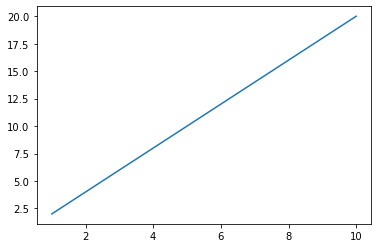

```python
# Line Plot
x=np.arange(1,11) # 11 is exclusive
x
y=2*x
y
plt.plot(x,y)
plt.show()
```

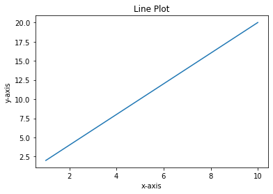

```python
# Line Plot with labels
x=np.arange(1,11) # 11 is exclusive
x
y=2*x
y
plt.plot(x,y)
plt.title("Line Plot")
plt.xlabel("x-axis")
plt.ylabel("y-axis")
plt.show()
```

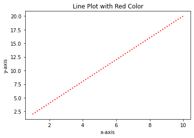

```python
# Line Plot with colour
plt.plot(x,y , color="red",linestyle=':',linewidth=2)
plt.title("Line Plot with Red Color")
plt.xlabel("x-axis")
plt.ylabel("y-axis")
plt.show()
```

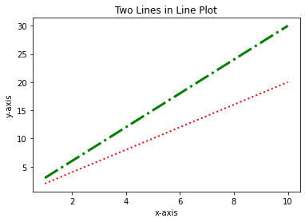

```python
# Adding two Lines in the same Plot
z=3*x
plt.plot(x,y , color="red",linestyle=':',linewidth=2)
plt.plot(x,z , color="green",linestyle='-.',linewidth=3)
plt.title("Two Lines in Line Plot")
plt.xlabel("x-axis")
plt.ylabel("y-axis")
plt.show()
```

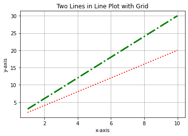

```python
# Adding two Lines in the same Plot with Grid
z=3*x
plt.plot(x,y , color="red",linestyle=':',linewidth=2)
plt.plot(x,z , color="green",linestyle='-.',linewidth=3)
plt.title("Two Lines in Line Plot with Grid")
plt.xlabel("x-axis")
plt.ylabel("y-axis")
plt.grid(True)
plt.show()
```

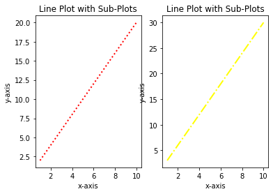

```python
# Adding sub - Plot column-wise
plt.subplot(1,2,1)
plt.plot(x,y , color="red",linestyle=':',linewidth=2)
plt.title("Line Plot with Sub-Plots")
plt.xlabel("x-axis")
plt.ylabel("y-axis")

plt.subplot(1,2,2)
plt.plot(x,z , color="yellow",linestyle='-.',linewidth=2)
plt.title("Line Plot with Sub-Plots")
plt.xlabel("x-axis")
plt.ylabel("y-axis")
plt.show()
```

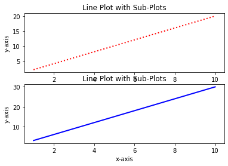

```python
# Adding sub - Plot row-wise
plt.subplot(2,1,1)
plt.plot(x,y , color="red",linestyle=':',linewidth=2)
plt.title("Line Plot with Sub-Plots")
plt.xlabel("x-axis")
plt.ylabel("y-axis")

plt.subplot(2,1,2)
plt.plot(x,z , color="blue",linewidth=2)
plt.title("Line Plot with Sub-Plots")
plt.xlabel("x-axis")
plt.ylabel("y-axis")
plt.show()
```

## (II) Bar Plot

*(i) Bar Plot b/w x & y:-*  
*Syntax:*  
plt.bar(x,y)  
plt.show()  
*(ii) Bar Plot with Titles and Grid*  
*Syntax:*  
plt.bar(x,y)  
plt.title("title_name")  
plt.xlabel("x-label")  
plt.ylabel("y-label")  
plt.grid(True)  
plt.show()  
*(iii) Horizontal Bar Plot with Titles and Grid*  
*Syntax:*  
plt.barh(x,y,color="color_name")  
plt.title("title_name")  
plt.xlabel("x-label")  
plt.ylabel("y-label")  
plt.grid(True)  
plt.show()

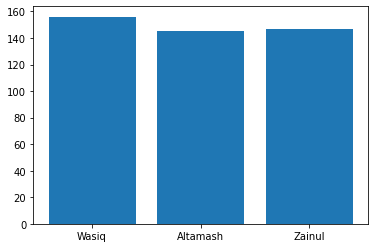

```python
# (i) Bar Plot b/w x & y:-
student = {"Wasiq":156,"Altamash":145,"Zainul":147}
names=list(student.keys())
values=list(student.values())
plt.bar(names,values)
plt.show()
```

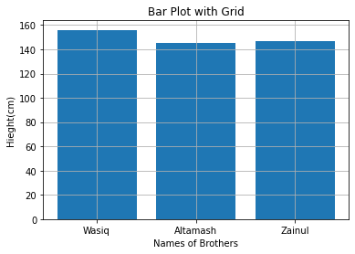

```python
# (ii) Bar Plot with Titles and Grid
plt.bar(names,values)
plt.title("Bar Plot with Grid")
plt.xlabel("Names of Brothers")
plt.ylabel("Hieght(cm)")
plt.grid(True)
plt.show()
```

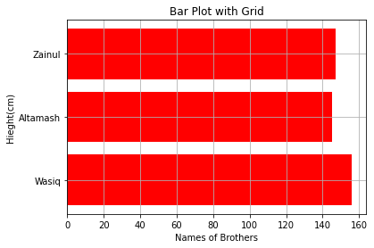

```python
# (iii) Horizontal Bar Plot with Titles and Grid
plt.barh(names,values, color="red")
plt.title("Bar Plot with Grid")
plt.xlabel("Names of Brothers")
plt.ylabel("Hieght(cm)")
plt.grid(True)
plt.show()
```

## (III) Scatter Plot

*(i) Scatter Plot b/w x & y:-*  
**Syntax:**  
plt.scatter(x,y)  
plt.show()  
*(ii) Scatter Plot with Aesthetics :-*  
*Syntax:*  
plt.scatter(x,y,marker="*",c="r",s=100) # c=color , r= red , s=size  
plt.show()  
*(iii) Adding two Markers in the Same Plot:-*  
*Syntax:*  
plt.scatter(x,y,marker="*",c="r",s=100)  
plt.scatter(x,z,marker=".",c="g",s=200)  
plt.show()  
*(iv) Adding sub-plots on Scatter Plot column-wise:-*  
*Syntax:*  
plt.subplot(1,2,1)  
plt.scatter(x,y,marker="*",c="r",s=100)  
plt.subplot(1,2,2)  
plt.scatter(x,z,marker=".",c="g",s=200)  
plt.show()  
*(v) Scatter Plot with Title and Grid:-*  
*Syntax:*  
plt.scatter(x,y,marker="*",c="r",s=100)  
plt.scatter(x,z,marker=".",c="g",s=200)  
plt.title("title")  
plt.xlabel("x-label")  
plt.ylabel("y-label")  
plt.grid(True)  
plt.show()

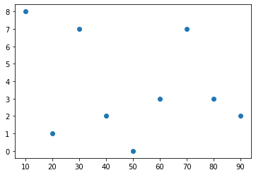

```python
# (i) Scatter Plot b/w x & y
x=[10,20,30,40,50,60,70,80,90]
y=[8,1,7,2,0,3,7,3,2]

plt.scatter(x,y)
plt.show()
```

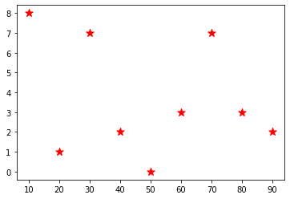

```python
# (ii) Scatter Plot with Aesthetics
plt.scatter(x,y,marker="*",c="r",s=100)
plt.show()
```

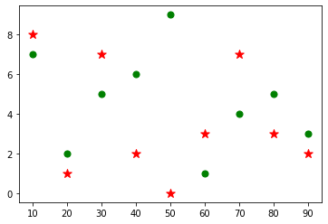

```python
# (iii) Adding two Markers in the Same Plot
z=[7,2,5,6,9,1,4,5,3]
plt.scatter(x,y,marker="*",c="r",s=100)
plt.scatter(x,z,marker=".",c="g",s=200)
plt.show()
```

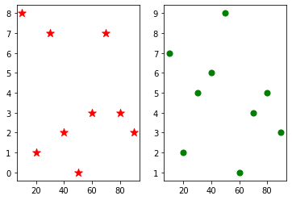

```python
# (iv) Adding sub-plots on Scatter Plot column-wise
plt.subplot(1,2,1)
plt.scatter(x,y,marker="*",c="r",s=100)

plt.subplot(1,2,2)
plt.scatter(x,z,marker=".",c="g",s=200)
plt.show()
```

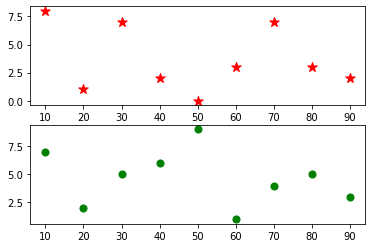

```python
# Adding sub-plots on Scatter Plot row-wise
plt.subplot(2,1,1)
plt.scatter(x,y,marker="*",c="r",s=100)

plt.subplot(2,1,2)
plt.scatter(x,z,marker=".",c="g",s=200)
plt.show()
```

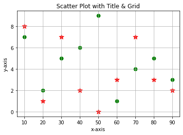

```python
# (v) Scatter Plot with Title and Grid
z=[7,2,5,6,9,1,4,5,3]
plt.scatter(x,y,marker="*",c="r",s=100)
plt.scatter(x,z,marker=".",c="g",s=200)
plt.title("Scatter Plot with Title & Grid")
plt.xlabel("x-axis")
plt.ylabel("y-axis")
plt.grid(True)
plt.show()
```

## (IV) Histogram

*(i) Histogram of data 'a' :-*  
*Syntax:*  
plt.hist(a)  
plt.show()  
*(ii) Histogram with Title and Grid of data 'a':-*  
*Syntax:*  
plt.hist(a , color='g' ,bins=4)  
plt.title("Title")  
plt.xlabel('x-label')  
plt.ylabel('y-label')  
plt.grid(True)  
plt.show()  
*(iii) Histogram of Imported Data(csv.file) of Data 'a' :-*  
*import pandas as pd*  
**vec_name=pd.read_csv('file_name.csv')**  
*Syntax:*  
plt.hist(a['column_name'],bins=30, color='r')  
plt.title("Title")  
plt.xlabel('x-label')  
plt.ylabel('y-label')  
plt.grid(True)  
plt.show()

```python
import numpy as np
```

```python
from matplotlib import pyplot as plt
```

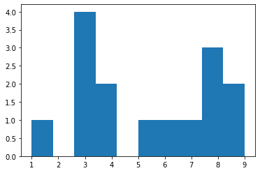

```python
# (i) Histogram
d2= [1,3,3,3,3,9,9,5,4,4,8,8,8,6,7]
plt.hist(d2)
plt.show()
```

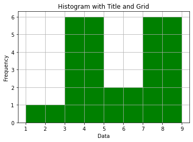

```python
# (ii) Histogram with Title and Grid
plt.hist(d2 , color='g' ,bins=4)
plt.title("Histogram with Title and Grid")
plt.xlabel('Data')
plt.ylabel('Frequency')
plt.grid(True)
plt.show()
```

```python
import pandas as pd
iris=pd.read_csv('iris.csv')
iris.head()
```

|  | Id | SepalLength | SepalWidth | PetalLength | PetalWidth | Species |
| --- | --- | --- | --- | --- | --- | --- |
| 0 | 1 | 5.1 | 3.5 | 1.4 | 0.2 | Iris-setosa |
| 1 | 2 | 4.9 | 3.0 | 1.4 | 0.2 | Iris-setosa |
| 2 | 3 | 4.7 | 3.2 | 1.3 | 0.2 | Iris-setosa |
| 3 | 4 | 4.6 | 3.1 | 1.5 | 0.2 | Iris-setosa |
| 4 | 5 | 5.0 | 3.6 | 1.4 | 0.2 | Iris-setosa |

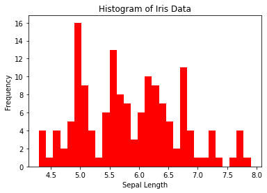

```python
# (iii) Histogram  of Imported Data
plt.hist(iris['SepalLength'],bins=30, color='r')
plt.title('Histogram of Iris Data')
plt.xlabel('Sepal Length')
plt.ylabel('Frequency')
plt.show()
```

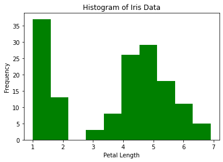

```python
plt.hist(iris['PetalLength'], color='g')
plt.title('Histogram of Iris Data')
plt.xlabel('Petal Length')
plt.ylabel('Frequency')
plt.show()
```

## (V) Box-Plot

*(i) Box-Plot of data 'a' :-*  
*Syntax:*  
plt.boxplot(a)  
plt.show()  
*(ii) Box-Plot with Title and Grid of data 'a' with Median:-*  
*Syntax:*  
plt.boxplot(a)  
plt.title("Title")  
plt.xlabel('x-label')  
plt.ylabel('y-label')  
plt.grid(True)  
plt.show()

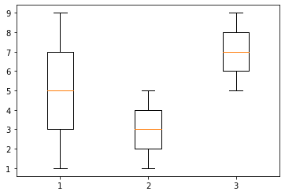

```python
# (i) Box-Plot of data 'a'
one=[1,2,3,4,5,6,7,8,9]
two=[1,2,3,4,5,4,3,2,1]
three=[6,7,8,9,8,7,6,5,5]
data=list([one,two,three])
plt.boxplot(data)
plt.show()
```

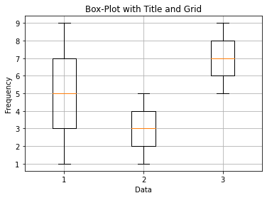

```python
# (ii) Box-Plot with Title and Grid
plt.boxplot(data)
plt.title("Box-Plot with Title and Grid")
plt.xlabel('Data')
plt.ylabel('Frequency')
plt.grid(True)
plt.show()
```

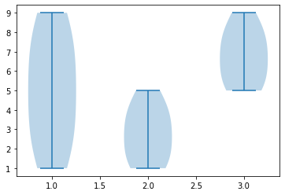

```python
## (i) Violin of data
plt.violinplot(data)
plt.show()
```

## (VI) Violin-Plot

*(i) Violin of data 'a' :-*  
*Syntax:*  
plt.violinplot(a)  
plt.show()  
*(ii) Violin-Plot with Title and Grid of data 'a' :-*  
*Syntax:*  
plt.violinplot(a,showmedians=True)  
plt.title("Title")  
plt.xlabel('x-label')  
plt.ylabel('y-label')  
plt.grid(True)  
plt.show()

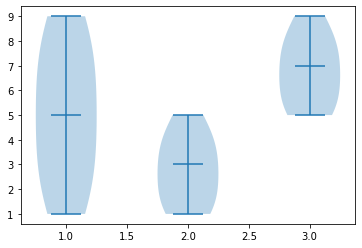

```python
## (i) Violin of data with Median
plt.violinplot(data,showmedians=True)
plt.show()
```

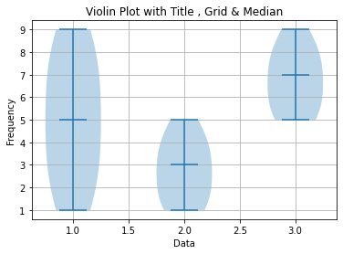

```python
# (ii) Violin-Plot with Title and Grid of data with Median
plt.violinplot(data,showmedians=True)
plt.title("Violin Plot with Title , Grid & Median")
plt.xlabel('Data')
plt.ylabel('Frequency')
plt.grid(True)
plt.show()
```

## (VII) Pie-Chart

(i) *Pie-Chart of data 'a' with Quantitative data 'q' and Qualitative data(Labels) 'l' :-*  
*Syntax:*  
plt.pie(q,labels=l)  
plt.show()  
*(ii) Pie-Chart with Title and Grid of data 'a' with Quantitative data 'q' and Qualitative data(Labels) 'l' with percentage of 'p' decimal places :-*  
*Syntax:*  
plt.pie(q,labels=l,autopct='%0.p%%,colors=['c_1','c_2',...,'c_n'])  
plt.title("Title")  
plt.xlabel('x-label')  
plt.ylabel('y-label')  
plt.show()

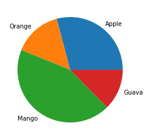

```python
# (i) Pie-Chart of with Quantitative data 'q' and Qualitative data(Labels) 'l'
fruit=['Apple','Orange','Mango','Guava']
quantity=[67,34,100,29]
plt.pie(quantity,labels=fruit)
plt.show()
```

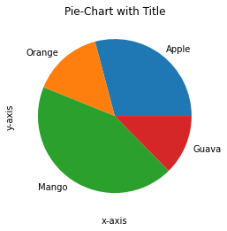

```python
# (ii) Pie-Chart with Title
plt.pie(quantity,labels=fruit)
plt.title("Pie-Chart with Title")
plt.xlabel('x-axis')
plt.ylabel('y-axis')
plt.show()
```

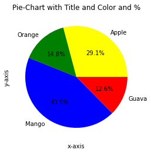

```python
# (iii) Pie-Chart with Title and Color
plt.pie(quantity,labels=fruit,autopct='%0.1f%%',colors=['yellow','green','blue','red'])
plt.title("Pie-Chart with Title and Color and %")
plt.xlabel('x-axis')
plt.ylabel('y-axis')
plt.show()
```

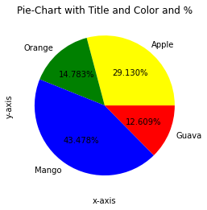

```python
plt.pie(quantity,labels=fruit,autopct='%0.3f%%',colors=['yellow','green','blue','red'])
plt.title("Pie-Chart with Title and Color and %")
plt.xlabel('x-axis')
plt.ylabel('y-axis')
plt.show()
```

## (VIII) DoughNut-Chart

*(i) DoughNut-Chart of data 'a' with Quantitative data 'q' and Qualitative data(Labels) 'l' :-*  
*Syntax:*  
plt.pie(q,labels=l,radius=2)  
plt.pie([1],colors=['w'],radius=1)  
plt.show()  
*(ii) DoughNut with Title and Grid of data 'a' with Quantitative data 'q' and Qualitative data(Labels) 'l' with percentage of 'p' decimal places :-*  
*Syntax:*  
plt.pie(q,labels=l,autopct='%0.p%%,colors=['c_1','c_2',...,'c_n'])  
plt.title("Title")  
plt.xlabel('x-label')  
plt.ylabel('y-label')  
plt.show()

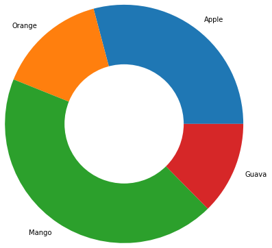

```python
 # DoughNut-Chart
## (i) DoughNut-Chart of data 'a' with Quantitative data 'q' and Qualitative data(Labels) 'l' and radiuses are 2 nd 1 .
plt.pie(quantity,labels=fruit,radius=2)
plt.pie([1],colors=['w'],radius=1)
plt.show()
```

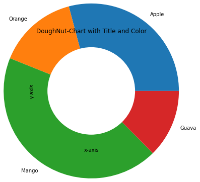

```python
## (ii) DoughNut-Chart of data 'a' with Quantitative data 'q' and Qualitative data(Labels) 'l' and radiuses are 2 nd 1 .
plt.pie(quantity,labels=fruit,radius=2)
plt.pie([1],colors=['w'],radius=1)
plt.title("DoughNut-Chart with Title and Color")
plt.xlabel('x-axis')
plt.ylabel('y-axis')
plt.show()
```

# (IV) SeaBorn Library:-

The Python visualization library Seaborn is based on matplotlib and provides a high-level interface for drawing attractive statistical graphics. It's also contains In-built Datasets .  
*import seaborn as sns*  
*from matplotlib import as plt*

## Graphics using SeaBorn Library :

The basic steps to creating plots with Seaborn are:  
*1. Prepare some data 2. Control figure aesthetics 3. Plot with Seaborn 4. Further customize your plot 5. Show Graph*  
tips = sns.load_dataset("tips") $Step-1$  
sns.set_style("whitegrid") $Step-2$  
g = sns.lmplot(x="tip", y="total_bill", data=tips, aspect=2) $Step-3$  
g = (g.set_axis_labels("Tip","Total bill(USD)"). set(xlim=(0,10),ylim=(0,100)))  
plt.title("title") $Step-4$  
plt.show() $Step-5$  
*(1) Data - Load the in-built dataset from seaborn library .*  
*iris = sns.load_dataset("iris")*  
*(2) Figure Aesthetics -*  
**Create a figure and one subplot : plt.subplots(figsize=(5,6))**  
*(i) Seaborn Style :*  
(Re)set the seaborn default : **sns.set()**  
Set the matplotlib parameters : **sns.set_style("whitegrid")**  
Set the matplotlib parameters : **sns.set_style("ticks", {"xtick.major.size":8,"ytick.major.size":8})**  
Return a dict of params or use with with to temporarily set the style : **sns.axes_style("whitegrid")**  
*(ii) Context Functions :*  
Set context to "talk" : **sns.set_context("talk")**  
Set context to "notebook", Scale font elements and override param mapping : **sns.set_context("notebook", font_scale=1.5, rc={"lines.linewidth":2.5})**  
*(iii) Color Palette :*  
Define the color palette : **sns.set_palette("husl",3)**  
Use with with to temporarily set palette : **sns.color_palette("husl")**  
*(3) Plotting with Seaborn -*  
*(i) Axis Grids :*  
Subplot grid for plotting conditional relationships : **sns.FacetGrid(titanic, col="survived", row="sex")**  
**g.map(plt.hist,"age")**  
Draw a categorical plot onto a Facetgrid : **sns.factorplot(x="pclass", y="survived", hue="sex",data=titanic)**  
Plot data and regression model fits across a FacetGrid : **sns.lmplot(x="sepal_width", y="sepal_length", hue="species", data=iris)**  
Subplot grid for plotting pairwise : **sns.PairGrid(iris)**  
Relationships : **h.map(plt.scatter)**  
Plot pairwise bivariate distributions : **sns.pairplot(iris)**  
Grid for bivariate plot with marginal univariate plots : **sns.JointGrid(x="x",y="y",data=data)**  
**i.plot(sns.regplot,sns.distplot)**  
Plot bivariate distribution: **sns.jointplot("sepal_length", "sepal_width", data=iris, kind='kde')**  
*(ii) Categorical Plots :*  
(a) Scatterplot with one categorical variable : **sns.stripplot(x="species", y="petal_length", data=iris)**  
Categorical scatterplot with non-overlapping points : **sns.swarmplot(x="species",y="petal_length", data=iris)**  
(b) *Bar Chart*- Show point estimates and confidence intervals with scatterplot glyphs :**sns.barplot(x="sex",y="survived",y="survived",data=titanic)**  
(c) *Count Plot*- Show count of observations : **sns.countplot(x="deck", data=titanic, palette="Greens_d")**  
(d) *Point Plot*- Show point estimates and confidencentervals as rectangular bars : **sns.pointplot(x="class", y="survived", hue="sex", data=titanic,palette={"male":"g","female":"m"},markers=["^", "o"],linestyles=["-", "--"])**  
(e) *Boxplot* : **sns.boxplot(x="alive", y="age", hue="adult_male", data=titanic)**  
Boxplot with wide-form data : **sns.boxplot(data=iris,orient="h")**  
(f) *Violin-Plot* : **sns.violinplot(x="age", y="sex",hue="survived",data=titanic)**  
*(iii) Regression Plots :*  
Plot data and a linear regression model fit : **sns.regplot(x="sepal_width", y="sepal_length", data=iris,ax=ax)**  
(iv) *Distribution Plot :*  
Plot univariate distribution : **plot = sns.distplot(data.y, kde=False, color="b")**  
*(v) Matrix Plot :*  
*Heatmap* : **sns.heatmap(uniform_data,vmin=0,vmax=1)**  
*(4) Further Customizations-*  
*(i) Axisgrid Objects :*  
Remove left spine : **g.despine(left=True)**  
Set the labels of the y-axis : **g.set_ylabels("Survived")**  
Set the tick labels for x : **g.set_xticklabels(rotation=45)**  
Set the axis labels : **g.set_axis_labels("Survived", "Sex")**  
Set the limit and ticks of the x-and y-axis : **h.set(xlim=(0,5), ylim=(0,5), xticks=[0,2.5,5], yticks=[0,2.5,5] )**  
*(ii) Plot :*  
Add plot title : **plt.title("A Title")**  
Adjust the label of the y-axis : **plt.ylabel("Survived")**  
Adjust the label of the x-axis : **plt.xlabel("Sex")**  
Adjust the limits of the y-axis : **plt.ylim(0,100)**  
Adjust the limits of the x-axis : **plt.xlim(0,10)**  
Adjust a plot property : **plt.setp(ax,yticks=[0,5])**  
Adjust subplot params : **plt.tight_layout()**  
*(5) Show or Save Plot -*  
Show the plot : **plt.show()**  
Save the plot as a figure : **plt.savefig("foo.png")**  
Save transparent figure : **plt.savefig("foo.png", transparent=True)**  
*(6) Close & Clear -*  
Clear an axis : **plt.cla()**  
Clear an entire figure : **plt.savefig("foo.png")**  
Save transparent figure : **plt.savefig("foo.png", transparent=True)**

```python
import seaborn as sns
```

```python
from matplotlib import pyplot as plt
```

```python
sns.__version__  # seaborn version
```

```
'0.11.1'
```

```python
sns.get_dataset_names()
```

```
['anagrams',
 'anscombe',
 'attention',
 'brain_networks',
 'car_crashes',
 'diamonds',
 'dots',
 'exercise',
 'flights',
 'fmri',
 'gammas',
 'geyser',
 'iris',
 'mpg',
 'penguins',
 'planets',
 'taxis',
 'tips',
 'titanic']
```

```python
fmri= sns.load_dataset('fmri')
fmri.head()
```

|  | subject | timepoint | event | region | signal |
| --- | --- | --- | --- | --- | --- |
| 0 | s13 | 18 | stim | parietal | -0.017552 |
| 1 | s5 | 14 | stim | parietal | -0.080883 |
| 2 | s12 | 18 | stim | parietal | -0.081033 |
| 3 | s11 | 18 | stim | parietal | -0.046134 |
| 4 | s10 | 18 | stim | parietal | -0.037970 |

```python
fmri.head()
```

|  | subject | timepoint | event | region | signal |
| --- | --- | --- | --- | --- | --- |
| 0 | s13 | 18 | stim | parietal | -0.017552 |
| 1 | s5 | 14 | stim | parietal | -0.080883 |
| 2 | s12 | 18 | stim | parietal | -0.081033 |
| 3 | s11 | 18 | stim | parietal | -0.046134 |
| 4 | s10 | 18 | stim | parietal | -0.037970 |

```python
fmri.shape
```

```
(1064, 5)
```

## SeaBorn Graphics :

*(I) SeaBorn Line Plot:-*  
*(i) Line-plot of data 'a':*  
*Syntax:*  
sns.lineplot(x="col_name_1", y="col_name_2", data=a)  
plt.show()  
*(ii) Grouping Data with 'hue' in Line-plot:*  
hue is used to extract the color according to catagories  
*Syntax:*  
sns.lineplot(x="col_name_1", y="col_name_2", data=a,hue="col_name_3")  
plt.show()  
*(iii) Adding Style on Line Plot:*  
*Syntax:*  
sns.lineplot(x="col_name_1", y="col_name_2", data=a,hue="col_name_3"),style="col_name_3")  
plt.show()  
*(iv) Adding Title and Grid on Line Plot:*  
*Syntax:*  
sns.lineplot(x="col_name_1", y="col_name_2", data=a,hue="col_name_3"),style="col_name_3")  
plt.title("Title")  
plt.xlabel('x-label')  
plt.ylabel('y-label')  
plt.show()  
*(v) Adding Markers on Line Plot*  
*Syntax:*  
sns.lineplot(x="col_name_1", y="col_name_2",hue="col_name_3"),style="col_name_3",markers=True, data=a)  
plt.title("Title")  
plt.xlabel('x-label')  
plt.ylabel('y-label')  
plt.show()

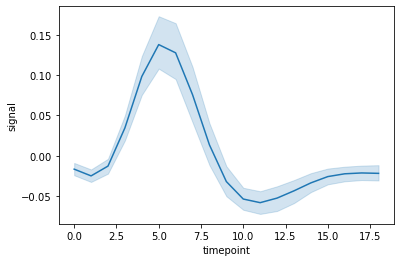

```python
# (i) Line-plot of data
sns.lineplot(x="timepoint", y="signal", data=fmri)
plt.show()
```

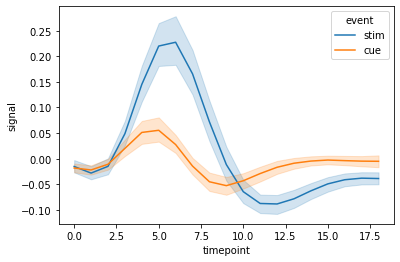

```python
# (ii) Grouping Data with 'hue' in Line-plot
sns.lineplot(x="timepoint", y="signal", data=fmri,hue="event")
plt.show()
```

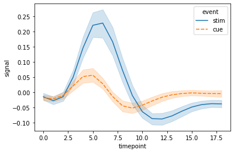

```python
# (iii) Adding Style on Line Plot
sns.lineplot(x="timepoint", y="signal", data=fmri,hue="event",style="event")
plt.show()
```

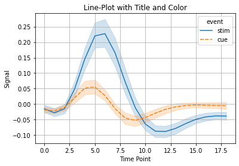

```python
# (iv) Adding Title on Line Plot
sns.lineplot(x="timepoint", y="signal", data=fmri,hue="event",style="event")
plt.title("Line-Plot with Title and Color")
plt.xlabel('Time Point')
plt.ylabel('Signal')
plt.grid(True)
plt.show()
```

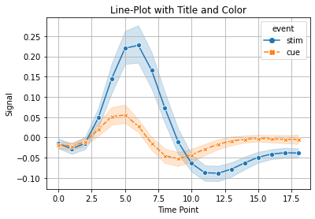

```python
# (v) Adding Markers on Line Plot
sns.lineplot(x="timepoint", y="signal",hue="event",style="event",markers=True,data=fmri)
plt.title("Line-Plot with Title and Color")
plt.xlabel('Time Point')
plt.ylabel('Signal')
plt.grid(True)
plt.show()
```

## (II) SeaBorn Bar-Plot

*To set white grid:*- **sns.set(style="whitegrid")**  
*(i) Bar-plot of data 'a':*  
*Syntax:*  
sns.barplot(x="col_name_1", y="col_name_2", data=a)  
plt.show()  
*(ii) Adding Title on Bar Plot :*  
*Syntax:*  
sns.barplot(x="col_name_1", y="col_name_2", data=a)  
plt.title("Title")  
plt.xlabel('x-label')  
plt.ylabel('y-label')  
plt.show()  
*(iii) Adding 'hue' on Bar Plot :*  
*Syntax:*  
sns.barplot(x="col_name_1", y="col_name_2", data=a,hue="col_name_3")  
plt.title("Title")  
plt.xlabel('x-label')  
plt.ylabel('y-label')  
plt.show()  
*(iv) Adding palette on Bar Plot. It's change the defaut color :*  
*Syntax:*  
sns.barplot(x="col_name_1", y="col_name_2", data=a,palette="rocket/Blues_d/vlag"),style="col_name_3")  
plt.show()  
*(v) Bar Plot with single color :*  
*Syntax:*  
sns.barplot(x="col_name_1", y="col_name_2",color='col_name')  
plt.title("Title")  
plt.xlabel('x-label')  
plt.ylabel('y-label')  
plt.show()

```python
import pandas as pd
sns.set(style="whitegrid")
pokemon=pd.read_csv('pokemon.csv')
pokemon.head()
```

|  | number | name | type1 | type2 | total | hp | attack | defense | sp_attack | sp_defense | speed | generation | legendary |
| --- | --- | --- | --- | --- | --- | --- | --- | --- | --- | --- | --- | --- | --- |
| 0 | 1 | Bulbasaur | Grass | Poison | 318 | 45 | 49 | 49 | 65 | 65 | 45 | 1 | False |
| 1 | 2 | Ivysaur | Grass | Poison | 405 | 60 | 62 | 63 | 80 | 80 | 60 | 1 | False |
| 2 | 3 | Venusaur | Grass | Poison | 525 | 80 | 82 | 83 | 100 | 100 | 80 | 1 | False |
| 3 | 3 | Mega Venusaur | Grass | Poison | 625 | 80 | 100 | 123 | 122 | 120 | 80 | 1 | False |
| 4 | 3 | Gigantamax Venusaur | Grass | Poison | 525 | 80 | 82 | 83 | 100 | 100 | 80 | 1 | False |

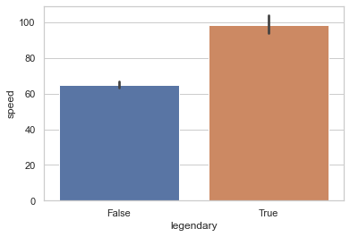

```python
# (i) Bar-Plot
sns.barplot(x="legendary", y="speed" , data=pokemon)
plt.show()
```

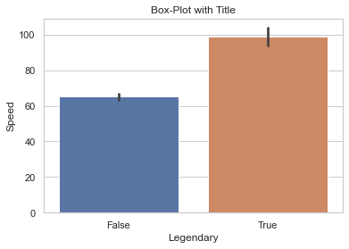

```python
# (ii) Bar-Plot with Title
sns.barplot(x="legendary", y="speed" , data=pokemon)
plt.title("Box-Plot with Title")
plt.xlabel('Legendary')
plt.ylabel('Speed')
plt.show()
```

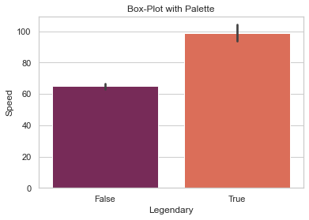

```python
# (iii) Bar-Plot with Palette
sns.barplot(x="legendary", y="speed" , data=pokemon , palette='rocket')
plt.title("Box-Plot with Palette")
plt.xlabel('Legendary')
plt.ylabel('Speed')
plt.show()
```

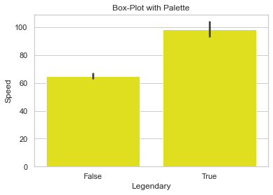

```python
# (iii) Bar-Plot with Same Color
sns.barplot(x="legendary", y="speed" , data=pokemon , color='yellow')
plt.title("Box-Plot with Palette")
plt.xlabel('Legendary')
plt.ylabel('Speed')
plt.show()
```

# (III) SeaBorn

### (A) Scatter-Plot

*To set white grid*:- **sns.set(style="whitegrid")**  
*(i) Scatter-plot of data 'a' :*  
*Syntax:*  
sns.scatteplot(x="col_name_1", y="col_name_2", data=a)  
plt.show()  
*(ii) Adding Title on Scatter Plot :*  
*Syntax:*  
sns.scatterplot(x="col_name_1", y="col_name_2", data=a)  
plt.title("Title")  
plt.xlabel('x-label')  
plt.ylabel('y-label')  
plt.show()  
*(iii) Adding 'hue' on Scatter Plot :*  
*Syntax:*  
sns.scatterplot(x="col_name_1", y="col_name_2", data=a,hue="col_name_3",style="col_name_3")  
plt.title("Title")  
plt.title("Title")  
plt.xlabel('x-label')  
plt.ylabel('y-label')  
plt.show()

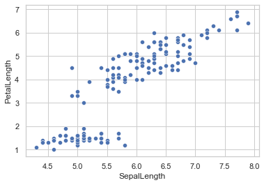

```python
# (A) Scatter-Plot
iris=pd.read_csv('iris.csv')
sns.scatterplot(x="SepalLength", y="PetalLength" , data=iris)
plt.show()
```

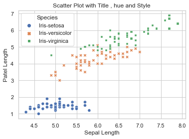

```python
# (ii) Scatter plot with Title and hue and style
sns.scatterplot(x="SepalLength", y="PetalLength" , data=iris, hue="Species",style="Species")
plt.title("Scatter Plot with Title , hue and Style")
plt.xlabel('Sepal Length')
plt.ylabel('Patel Length')
plt.show()
```

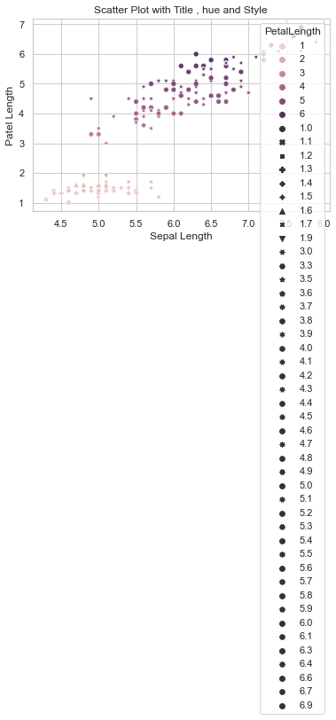

```python
sns.scatterplot(x="SepalLength", y="PetalLength" , data=iris, hue="PetalLength",style="PetalLength")
plt.title("Scatter Plot with Title , hue and Style")
plt.xlabel('Sepal Length')
plt.ylabel('Patel Length')
plt.show()
```

## (B) SeaBorn Histogram/Distplot

*To set white grid*:- **sns.set(style="whitegrid")**  
*(i) Distplot with Histogram of data 'a' :*  
*Syntax*  
sns.distplot(a['col_name'],colo='col_name')  
plt.show  
*(ii) Distplot without Histogram of data 'a' :*  
*Syntax:*  
sns.distplot(a['col_name'],hist=False)  
plt.show()  
*(iii) Adding Title on Distplot :*  
*Syntax:*  
sns.distplot(a['col_name'])  
plt.title("Title")  
plt.xlabel('x-label')  
plt.ylabel('y-label')  
plt.show()  
*iv) Horizontal Distplot*  
*Syntax:*  
sns.distplot(a['col_name'],color='col_name',vertical=True)  
plt.title("Title")  
plt.xlabel('x-label')  
plt.ylabel('y-label')  
plt.show()

```python
diamonds=pd.read_csv('diamonds.csv')
diamonds.head()
```

|  | Unnamed: 0 | carat | cut | color | clarity | depth | table | price | x | y | z |
| --- | --- | --- | --- | --- | --- | --- | --- | --- | --- | --- | --- |
| 0 | 1 | 0.23 | Ideal | E | SI2 | 61.5 | 55.0 | 326 | 3.95 | 3.98 | 2.43 |
| 1 | 2 | 0.21 | Premium | E | SI1 | 59.8 | 61.0 | 326 | 3.89 | 3.84 | 2.31 |
| 2 | 3 | 0.23 | Good | E | VS1 | 56.9 | 65.0 | 327 | 4.05 | 4.07 | 2.31 |
| 3 | 4 | 0.29 | Premium | I | VS2 | 62.4 | 58.0 | 334 | 4.20 | 4.23 | 2.63 |
| 4 | 5 | 0.31 | Good | J | SI2 | 63.3 | 58.0 | 335 | 4.34 | 4.35 | 2.75 |

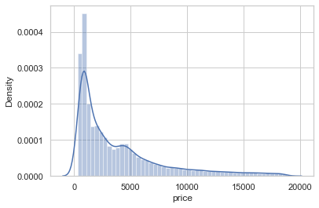

```python
# Distplot with histogram of data
sns.distplot(diamonds['price'])
plt.show()
```

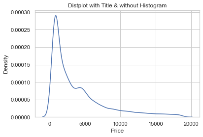

```python
# (ii) Distplot without Histogram and with title
sns.distplot(diamonds['price'], hist=False)
plt.title("Distplot with Title & without Histogram")
plt.xlabel('Price')
plt.ylabel('Density')
plt.show()
```

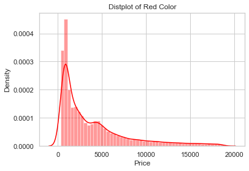

```python
sns.distplot(diamonds['price'], color="red")
plt.title("Distplot of Red Color")
plt.xlabel('Price')
plt.ylabel('Density')
plt.show()
```

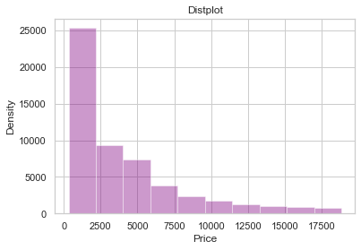

```python
# Remove the frequency
sns.distplot(diamonds['price'], color='purple',bins=10,kde=False)
plt.title("Distplot")
plt.xlabel('Price')
plt.ylabel('Density')
plt.show()
```

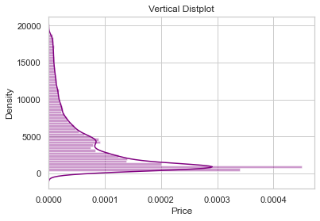

```python
# Horizontal Distplot
sns.distplot(diamonds['price'], color='purple',vertical=True)
plt.title("Vertical Distplot")
plt.xlabel('Price')
plt.ylabel('Density')
plt.show()
```

## (C) SeaBorn Joint-Plot

*To set white grid:*- **sns.set(style="whitegrid")**  
*(i) Joint-plot of data 'a' :*  
*Syntax:*  
s.jointplot(x="col_name_1", y="col_name_2", data=a)  
plt.show()  
*(ii) Adding Title on Joint Plot*  
*Syntax:*  
sns.jointplot(x="col_name_1", y="col_name_2", data=a,color='col_name')  
plt.title("Title")  
plt.xlabel('x-label')  
plt.ylabel('y-label')  
plt.show()  
*(iii) Adding Regression Model on Joint Plot :*  
*Syntax:*  
sns.jointplot(x="col_name_1", y="col_name_2", data=a,kind="reg")  
plt.title("Title")  
plt.title("Title")  
plt.xlabel('x-label')  
plt.ylabel('y-label')  
plt.show()

```python
# Joint-Plot of Iris Data
iris=pd.read_csv('iris.csv')
iris.head()
```

|  | Id | SepalLength | SepalWidth | PetalLength | PetalWidth | Species |
| --- | --- | --- | --- | --- | --- | --- |
| 0 | 1 | 5.1 | 3.5 | 1.4 | 0.2 | Iris-setosa |
| 1 | 2 | 4.9 | 3.0 | 1.4 | 0.2 | Iris-setosa |
| 2 | 3 | 4.7 | 3.2 | 1.3 | 0.2 | Iris-setosa |
| 3 | 4 | 4.6 | 3.1 | 1.5 | 0.2 | Iris-setosa |
| 4 | 5 | 5.0 | 3.6 | 1.4 | 0.2 | Iris-setosa |

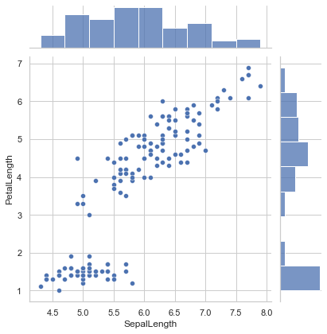

```python
# (C) Joint Plot
sns.jointplot(x='SepalLength', y='PetalLength',data=iris)
plt.show()
```

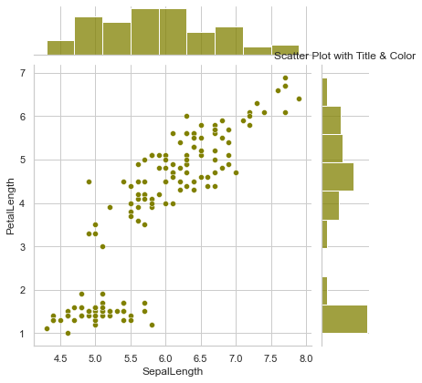

```python
# (ii) Joint-Plot with Title and colour
sns.jointplot(x='SepalLength', y='PetalLength',data=iris,color='olive')
plt.title("Scatter Plot with Title & Color")
plt.xlabel('Sepal Length')
plt.ylabel('Patel Length')
plt.show()
```

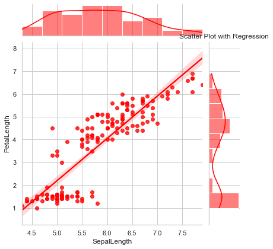

```python
# (iii) Joint-Plot with Regression
sns.jointplot(x='SepalLength', y='PetalLength',data=iris,color='red',kind="reg")
plt.title("Scatter Plot with Regression")
plt.xlabel('Sepal Length')
plt.ylabel('Patel Length')
plt.show()
```

## (D) SeaBorn Box-Plot

*To set white grid:*- **sns.set(style="whitegrid")**  
*(i) Box-plot of data 'a' :*  
*Syntax:*  
sns.boxplot(x="col_name_1", y="col_name_2", data=a)  
plt.show()  
*(ii) Adding Title & palette on Box Plot :*  
*Syntax:*  
sns.boxplot(x="col_name_1", y="col_name_2", data=a,palette='col_name')  
plt.title("Title")  
plt.xlabel('x-label')  
plt.ylabel('y-label')  
plt.show()  
*(iii) Box Plot with palette :*  
*Syntax:*  
sns.boxplot(x="col_name_1", y="col_name_2", data=a,palette="Set1")  
plt.show()  
*(iv) Box Plot within Order :*  
*Syntax:*  
sns.boxplot(x="col_name_1", y="col_name_2", data=a,order=["A","B",.....,"Z"])  
plt.show()  
*(v) Adding 'hue' on Box Plot :*  
*Syntax:*  
sns.boxplot(x="col_name_1", y="col_name_2", data=a,hue="col_name_3")  
plt.show()

```python
churn=pd.read_csv('chrn.csv')
churn.head()
```

|  | customerID | gender | SeniorCitizen | Partner | Dependents | tenure | PhoneService | MultipleLines | InternetService | OnlineSecurity | ... | DeviceProtection | TechSupport | StreamingTV | StreamingMovies | Contract | PaperlessBilling | PaymentMethod | MonthlyCharges | TotalCharges | Churn |
| --- | --- | --- | --- | --- | --- | --- | --- | --- | --- | --- | --- | --- | --- | --- | --- | --- | --- | --- | --- | --- | --- |
| 0 | 7590-VHVEG | Female | 0 | Yes | No | 1 | No | No phone service | DSL | No | ... | No | No | No | No | Month-to-month | Yes | Electronic check | 29.85 | 29.85 | No |
| 1 | 5575-GNVDE | Male | 0 | No | No | 34 | Yes | No | DSL | Yes | ... | Yes | No | No | No | One year | No | Mailed check | 56.95 | 1889.5 | No |
| 2 | 3668-QPYBK | Male | 0 | No | No | 2 | Yes | No | DSL | Yes | ... | No | No | No | No | Month-to-month | Yes | Mailed check | 53.85 | 108.15 | Yes |
| 3 | 7795-CFOCW | Male | 0 | No | No | 45 | No | No phone service | DSL | Yes | ... | Yes | Yes | No | No | One year | No | Bank transfer (automatic) | 42.30 | 1840.75 | No |
| 4 | 9237-HQITU | Female | 0 | No | No | 2 | Yes | No | Fiber optic | No | ... | No | No | No | No | Month-to-month | Yes | Electronic check | 70.70 | 151.65 | Yes |

5 rows × 21 columns

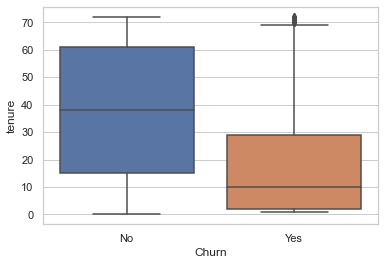

```python
# (i) Box Plot
sns.boxplot(x='Churn', y='tenure',data=churn)
plt.show()
```

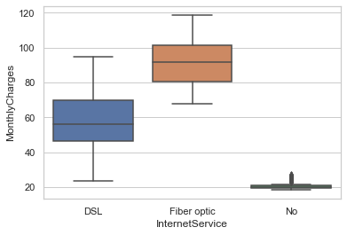

```python
sns.boxplot(x='InternetService', y='MonthlyCharges',data=churn)
plt.show()
```

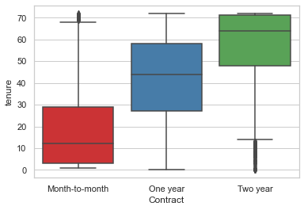

```python
# (ii) Box Plot with palette
sns.boxplot(x='Contract', y='tenure',data=churn,palette="Set1")
plt.show()
```

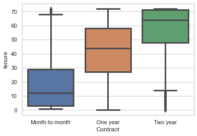

```python
# (iii) Box Plot with LineWidth
sns.boxplot(x='Contract', y='tenure',data=churn,linewidth=3)
plt.show()
```

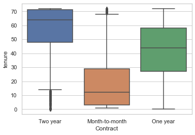

```python
# (iv) Box Plot within Order
sns.boxplot(x='Contract', y='tenure',data=churn,order=["Two year","Month-to-month","One year"])
plt.show()
```

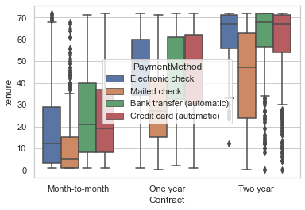

```python
# (v) Box Plot with hue
sns.boxplot(x='Contract', y='tenure',data=churn,hue="PaymentMethod")
plt.show()
```

## (E) SeaBorn Pair-Plot

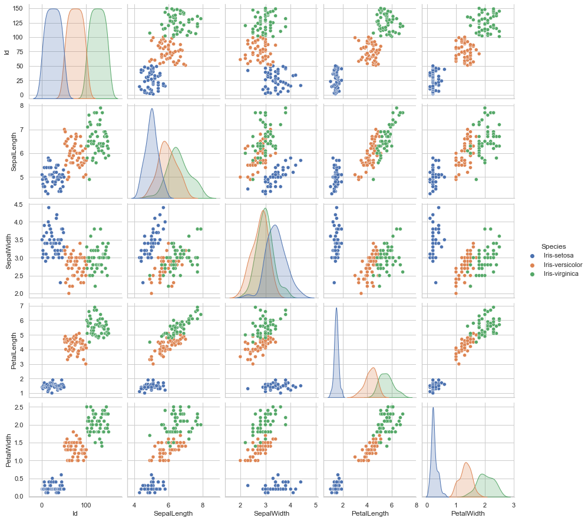

```python
df=pd.read_csv("iris.csv")
sns.pairplot(df,hue="Species")
plt.show()
```

```python
df1=sns.load_dataset("iris")
df1.head()
```

|  | sepal_length | sepal_width | petal_length | petal_width | species |
| --- | --- | --- | --- | --- | --- |
| 0 | 5.1 | 3.5 | 1.4 | 0.2 | setosa |
| 1 | 4.9 | 3.0 | 1.4 | 0.2 | setosa |
| 2 | 4.7 | 3.2 | 1.3 | 0.2 | setosa |
| 3 | 4.6 | 3.1 | 1.5 | 0.2 | setosa |
| 4 | 5.0 | 3.6 | 1.4 | 0.2 | setosa |

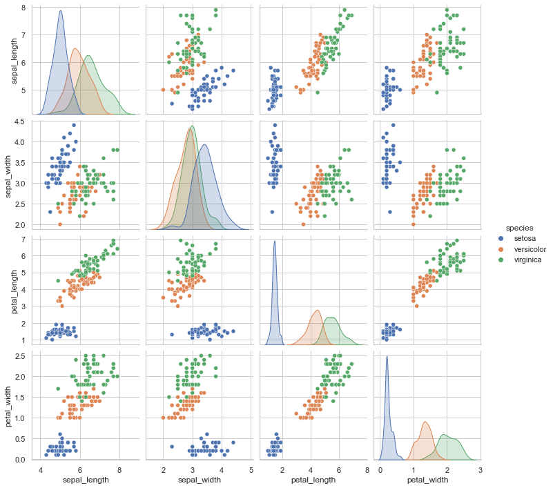

```python
sns.pairplot(df1,hue="species")
plt.show()
```

```python
# Timing:-  6:55:00
```

```python
import pingouin as pg
```